# STA 9750 Mini-Project #01: Netflix Analysis

Eduardo Alarcon

```r
library(dplyr)
library(lubridate)
library(readr)
library(scales)
library(tidyverse)
library(knitr)
library(ggplot2)
```

## Task 4

The following questions address Task 4. Please click on the “Show Code” for an detailed approach on how I obtained my results.

1. How many different countries does Netflix operate in? (You can use the viewing history as a proxy for countries in which Netflix operates.)

```r
n_distinct(COUNTRY_TOP_10$country_name)
```

```
## [1] 94
```

**Answer:** Netflix operates in `94` different countries based on the viewing history data.

2. Which non-English-language film has spent the most cumulative weeks in the global top 10? How many weeks did it spend?

```r
Q2_RESULT <- GLOBAL_TOP_10 %>%
filter(category == "Films (Non-English)") %>%
group_by(show_title) %>%
summarise(`Maximum Cumulative Weeks` = max(cumulative_weeks_in_top_10, na.rm = TRUE)) %>%
arrange(desc(`Maximum Cumulative Weeks`)) %>%
slice(1)

film_name_2 <- Q2_RESULT$show_title
weeks_count_2 <- Q2_RESULT[[2]]

Q2_RESULT %>%
format_titles() %>%
datatable(options = list(searching = FALSE, info = FALSE, paging = FALSE, columnDefs = list(list(className = 'dt-left', targets = "_all"))))
```

|  | Show Title | Maximum Cumulative Weeks |
| --- | --- | --- |
| 1 | All Quiet on the Western Front | 23 |

**Answer:** The non-English-language film All Quiet on the Western Front spent the most cumulative weeks in the Global Top 10, with 23 weeks.

3. What is the longest film (English or non-English) to have ever appeared in the Netflix global Top 10? How long is it in minutes?

```r
Q3_RESULT <- GLOBAL_TOP_10 %>%
  filter(category %in% c("Films (Non-English)", "Films (English)")) %>%
  filter(!is.na(runtime)) %>%
  group_by(show_title) %>%
  summarise(max_runtime = max(runtime)) %>%
  arrange(desc(max_runtime)) %>%
  slice(1) %>%
  mutate(max_runtime_minutes = round(60 * max_runtime))

film_name_3 <- Q3_RESULT$show_title
run_time_3 <- Q3_RESULT[[3]]

Q3_RESULT %>%
select(-max_runtime) %>%
format_titles() %>%
datatable(options = list(searching = FALSE, info = FALSE, paging = FALSE, columnDefs = list(list(className = 'dt-left', targets = "_all"))))
```

|  | Show Title | Max Runtime Minutes |
| --- | --- | --- |
| 1 | Pushpa 2: The Rule (Reloaded Version) | 224 |

**Answer:** The longest English or non-English film to have ever topped in the Netflix Global Top 10 is Pushpa 2: The Rule (Reloaded Version), with a length of 224 minutes.

4. For each of the four categories, what program has the most total hours of global viewership?

```r
Q4_RESULT <- GLOBAL_TOP_10 %>%
group_by(category, show_title) %>%
summarise(total_hours_global_viewership = sum(weekly_hours_viewed, na.rm = TRUE), .groups = "drop") %>%
group_by(category) %>%
slice_max(total_hours_global_viewership, n = 1) %>%
arrange(desc(total_hours_global_viewership)) %>%
mutate(total_hours_global_viewership = comma(total_hours_global_viewership))

Q4_RESULT %>%
format_titles() %>%
datatable(options = list(searching = FALSE, info = FALSE, paging = FALSE, columnDefs = list(list(className = 'dt-left', targets = "_all"))))
```

|  | Category | Show Title | Total Hours Global Viewership |
| --- | --- | --- | --- |
| 1 | TV (Non-English) | Squid Game | 5,048,300,000 |
| 2 | TV (English) | Stranger Things | 2,967,980,000 |
| 3 | Films (English) | KPop Demon Hunters | 559,100,000 |
| 4 | Films (Non-English) | Society of the Snow | 235,900,000 |

**Answer:** The above table highlights calculations that sum all seasons together (i.e.,franchise-level data). In other words, Stranger Things and Squid Game reflect the combined global viewership across all of their respective seasons.

5. Which TV show had the longest run in a country’s Top 10? How long was this run and in what country did it occur?

```r
Q5_RESULT <- COUNTRY_TOP_10 %>%
filter(category == "TV") %>%
filter(!is.na(season_title)) %>%
group_by(country_name, show_title) %>%
summarise(max_cumulative_weeks = max(cumulative_weeks_in_top_10), .groups = "drop") %>%
arrange(desc(max_cumulative_weeks)) %>%
slice(1)

Q5_RESULT %>%
format_titles() %>%
datatable(options = list(searching = FALSE, info = FALSE, paging = FALSE, columnDefs = list(list(className = 'dt-left', targets = "_all"))))
```

|  | Country Name | Show Title | Max Cumulative Weeks |
| --- | --- | --- | --- |
| 1 | Pakistan | Money Heist | 127 |

**Answer:** Money Heist had the longest run in Pakistan, with 127 weeks in Netflix’s Country Top 10 list.

6. Netflix provides over 200 weeks of service history for all but one country in our data set. Which country is this and when did Netflix cease operations in that country?

```r
Q6_RESULT <- COUNTRY_TOP_10 %>%
group_by(country_name) %>%
summarise(total_weeks_of_data = n_distinct(week),final_week = max(week, na.rm = TRUE)) %>%
filter(total_weeks_of_data < 200) %>%
arrange(total_weeks_of_data)

Q6_RESULT %>%
format_titles() %>%
datatable(options = list(searching = FALSE, info = FALSE, paging = FALSE, columnDefs = list(list(className = 'dt-left', targets = "_all"))))
```

|  | Country Name | Total Weeks Of Data | Final Week |
| --- | --- | --- | --- |
| 1 | Russia | 35 | 2022-02-27 |

**Answer:** Netflix could not provide over 200 weeks of service for Russia, as it ceased operations during the week of February 27, 2022, resulting in 35 weeks of data in the Country Top 10 list.

7. What is the total viewership of the TV show Squid Game? Note that there are three seasons total and we are looking for the total number of hours watched across all seasons.

```r
Q7_RESULT_SEASONS <- GLOBAL_TOP_10 %>%
filter(show_title == "Squid Game") %>%
filter(!is.na(season_title)) %>%
group_by(season_title) %>%
summarise(sum_hours = sum(weekly_hours_viewed, na.rm = TRUE)) %>%
mutate(hours_watched = comma(sum_hours))

Q7_RESULT_SEASONS_SUM <- Q7_RESULT_SEASONS %>%
summarise(
season_title = "Total Hours Watched Across All Seasons",
sum_hours_1 = sum(sum_hours),
hours_watched = comma(sum_hours_1))

Q7_RESULT_FINAL <- bind_rows(Q7_RESULT_SEASONS, Q7_RESULT_SEASONS_SUM) %>%
select(season_title, hours_watched)

Q7_RESULT_FINAL %>%
format_titles() %>%
datatable(options = list(searching = FALSE, info = FALSE, paging = FALSE, columnDefs = list(list(className = 'dt-left', targets = "_all"))))
```

|  | Season Title | Hours Watched |
| --- | --- | --- |
| 1 | Squid Game: Season 1 | 2,729,400,000 |
| 2 | Squid Game: Season 2 | 1,445,500,000 |
| 3 | Squid Game: Season 3 | 873,400,000 |
| 4 | Total Hours Watched Across All Seasons | 5,048,300,000 |

**Answer:** Across all three seasons, Squid Game had a total of 5,048,300,000 hours of global viewership.

8. The movie Red Notice has a runtime of 1 hour and 58 minutes. Approximately how many views did it receive in 2021?

```r
library(dplyr)
library(lubridate)
library(scales)
library(DT)
library(tibble)

Q8_ROWS <- GLOBAL_TOP_10 %>%
  mutate(week = as.Date(week)) %>%
  filter(show_title == "Red Notice", year(week) == 2021)

if (nrow(Q8_ROWS) == 0) {
  Q8_RESULT <- tibble(
    `Total Hours Viewed (2021)` = "N/A",
    `Approximate Views` = "N/A"
  )
} else {
Q8_RESULT <- Q8_ROWS %>%
summarise(
total_hours_2021 = sum(weekly_hours_viewed, na.rm = TRUE),
runtime_hours = 1 + 58/60,  # 1h 58m
approximate_views = total_hours_2021 / runtime_hours) %>%
mutate(`Total Hours Viewed (2021)` = comma(total_hours_2021), `Approximate Views` = comma(round(approximate_views))) %>%
select(`Total Hours Viewed (2021)`, `Approximate Views`)
}

Q8_RESULT %>%
datatable(options = list( searching = FALSE, info = FALSE, paging = FALSE,
columnDefs = list(list(className = 'dt-left', targets = "_all"))))
```

|  | Total Hours Viewed (2021) | Approximate Views |
| --- | --- | --- |
| 1 | 396,740,000 | 201,732,203 |

**Answer:** Based on the total number of hours viewed in 2021, Red Notice has approximately, 201,732,203 global views.

9. Part A: How many Films reached Number 1 in the US but did not originally debut there?

```r
COUNTRY_TOP_10_US_ONLY <- COUNTRY_TOP_10 %>%
  filter(country_iso2 == "US", category == "Films") %>%
  mutate(week = as.Date(week))

US_FILMS_REACH1 <- COUNTRY_TOP_10_US_ONLY %>%
  group_by(show_title) %>%
  summarise(best_rank = min(weekly_rank, na.rm = TRUE), .groups = "drop") %>%
  filter(best_rank == 1)

US_DEBUT <- COUNTRY_TOP_10_US_ONLY %>%
  group_by(show_title) %>%
  arrange(week, .by_group = TRUE) %>%
  slice(1L) %>%
  ungroup() %>%
  transmute(show_title, debut_week = week, debut_rank = weekly_rank)

Q9_RESULT_PT1 <- US_FILMS_REACH1 %>%
  inner_join(US_DEBUT, by = "show_title") %>%
  filter(debut_rank > 1) %>%
  summarise(number_of_films = n())
```

**Answer:** A total of `45` films in the US reached to Number 1 after debuting at a lower ranking.

9. Part B: What is the most recent film to pull this off?

```r
Q9_RESULT_PT2 <- COUNTRY_TOP_10 %>%
filter(country_iso2 == "US", category == "Films") %>%
mutate(week = as.Date(week)) %>%
group_by(show_title) %>%
summarise(
debut_week = min(week),
debut_rank = weekly_rank[which.min(week)],
best_rank  = min(weekly_rank, na.rm = TRUE),
.groups = "drop") %>%
filter(best_rank == 1, debut_rank > 1) %>%
inner_join(COUNTRY_TOP_10 %>%
filter(country_iso2 == "US", category == "Films") %>%
mutate(week = as.Date(week)) %>%
select(show_title, week, weekly_rank), by = "show_title") %>%
filter(weekly_rank == 1) %>%
slice_max(order_by = week, n = 1, with_ties = FALSE) %>%
transmute(`Most Recent Film` = show_title, `Date Reached #1` = week)


Q9_RESULT_PT2 %>%
datatable(
  options = list(searching = FALSE, info = FALSE, paging = FALSE, columnDefs = list(list(className = 'dt-left', targets = "_all"))))
```

|  | Most Recent Film | Date Reached #1 |
| --- | --- | --- |
| 1 | KPop Demon Hunters | 2025-09-14 |

**Answer:** The most recent film to accomplish this was KPop Demon Hunters, which reached Number 1 during the week of September 14, 2025.

10. Which TV show/season hit the top 10 in the most countries in its debut week? In how many countries did it chart?

```r
COUNTRY_TOP_10_DEBUT <- COUNTRY_TOP_10 %>%
filter(category == "TV") %>%
group_by(show_title, season_title, country_name) %>%
summarise(
debut_week = min(week, na.rm = TRUE),
debut_rank = weekly_rank[which.min(week)][1],
.groups = "drop"
) %>%
arrange(debut_week)

Q10_RESULT <- COUNTRY_TOP_10_DEBUT %>%
group_by(show_title, season_title, debut_week) %>%
summarise(country_appearance = n_distinct(country_name), .groups = "drop") %>%
arrange(desc(country_appearance)) %>%
slice(1) %>%
rename(`Show Title` = show_title, `Season Title` = season_title, `Debut Week` = debut_week, `Number of Countries Charted` = country_appearance)

Q10_RESULT %>%
datatable(options = list(searching = FALSE, info = FALSE, paging = FALSE, columnDefs = list(list(className = 'dt-left', targets = "_all"))))
```

|  | Show Title | Season Title | Debut Week | Number of Countries Charted |
| --- | --- | --- | --- | --- |
| 1 | Emily in Paris | Emily in Paris: Season 2 | 2021-12-26 | 94 |

**Answer:** Emily in Paris (Season 2) charted in 94 countries during its debut week in December 26, 2021.

## Task 5:

## Press Release 1: Stranger Things

The following task involves creating a “Press Release” for the upcoming release of the final season of Stranger Things.

```r
STRANGE_GLOBAL_VIEWERSHIP <- GLOBAL_TOP_10 %>%
filter(show_title == "Stranger Things") %>%
mutate(season_display = ifelse(is.na(season_title), "Stranger Things: S1", season_title)) %>%
group_by(season_display) %>%
summarise(total_hours = sum(weekly_hours_viewed, na.rm = TRUE)) %>%
mutate(season_display = case_when(
season_display == "Stranger Things 2" ~ "Stranger Things: S2",
season_display == "Stranger Things 3" ~ "Stranger Things: S3",
season_display == "Stranger Things 4" ~ "Stranger Things: S4", TRUE ~ season_display)) %>%
mutate(avg_episode_minutes = case_when(
season_display == "Stranger Things: S1" ~ 47,
season_display == "Stranger Things: S2" ~ 60,
season_display == "Stranger Things: S3" ~ 60,
season_display == "Stranger Things: S4" ~ 87, TRUE ~ NA_real_),
avg_episode_hours = avg_episode_minutes / 60,
approximate_views = total_hours / avg_episode_hours,
total_hours_viewed = comma(total_hours),
approximate_viewership = comma(round(approximate_views))) %>%
arrange(season_display)

STRANGE_TOTAL_VIEWERSHIP <- STRANGE_GLOBAL_VIEWERSHIP %>%
filter(!is.na(avg_episode_minutes)) %>%
summarise(
season_display = "Totals",
total_hours = sum(total_hours),
total_views = sum(approximate_views, na.rm = TRUE),
avg_episode_minutes = NA_real_,
total_hours_viewed = comma(total_hours),
approximate_viewership = comma(round(total_views)))

STRANGE_VIEWERSHIP_SYNTH <- bind_rows(
STRANGE_GLOBAL_VIEWERSHIP %>% select(season_display, total_hours_viewed, avg_episode_minutes, approximate_viewership),
STRANGE_TOTAL_VIEWERSHIP %>% select(season_display, total_hours_viewed, avg_episode_minutes, approximate_viewership)
) %>%
rename( Season = season_display, `*Average Episode Minutes` = avg_episode_minutes)

STRANGE_VIEWERSHIP_SYNTH %>%
format_titles() %>%
datatable(
options = list(searching = FALSE, info = FALSE, paging = FALSE, columnDefs = list(list(className = 'dt-left', targets = "_all"))))
```

|  | Season | Total Hours Viewed | *Average Episode Minutes | Approximate Viewership |
| --- | --- | --- | --- | --- |
| 1 | Stranger Things: S1 | 372,450,000 | 47 | 475,468,085 |
| 2 | Stranger Things: S2 | 352,700,000 | 60 | 352,700,000 |
| 3 | Stranger Things: S3 | 355,520,000 | 60 | 355,520,000 |
| 4 | Stranger Things: S4 | 1,887,310,000 | 87 | 1,301,593,103 |
| 5 | Totals | 2,967,980,000 |  | 2,485,281,189 |

*Average minutes derived from the following sources:

*[Wikipedia’s List of Stranger Things Episodes](https://en.wikipedia.org/wiki/List_of_Stranger_Things_episodes)*

*[Netflix’s Official Tudum Blog](https://www.netflix.com/tudum/articles/stranger-things-season-4-episode-length)*

```r
STRANGE_POPULARITY <- GLOBAL_TOP_10 %>%
filter(show_title == "Stranger Things") %>%
mutate(season_display = ifelse(is.na(season_title), "Stranger Things: S1", season_title)) %>%
mutate(season_display = case_when(
season_display == "Stranger Things 2" ~ "Stranger Things: S2",
season_display == "Stranger Things 3" ~ "Stranger Things: S3",
season_display == "Stranger Things 4" ~ "Stranger Things: S4",
TRUE ~ season_display)) %>%
group_by(season_display) %>%
summarise(
weeks_in_top_10 = n_distinct(week),
weeks_at_number_1 = sum(weekly_rank == 1, na.rm = TRUE) ) %>%
arrange(season_display) %>%
rename(Season = season_display)

STRANGE_POPULARITY %>%
format_titles() %>%
datatable(
options = list(searching = FALSE, info = FALSE, paging = FALSE, columnDefs = list(list(className = 'dt-left', targets = "_all"))))
```

|  | Season | Weeks In Top 10 | Weeks At Number 1 |
| --- | --- | --- | --- |
| 1 | Stranger Things: S1 | 10 | 0 |
| 2 | Stranger Things: S2 | 10 | 0 |
| 3 | Stranger Things: S3 | 11 | 0 |
| 4 | Stranger Things: S4 | 19 | 7 |

```r
STRANGE_COUNTRY10_SUMMARY <- COUNTRY_TOP_10 %>%
filter(show_title == "Stranger Things") %>%
mutate(season_display = ifelse(is.na(season_title), "Stranger Things: S1", season_title)) %>%
group_by(country_name) %>%
summarise(total_weeks_in_top_10 = n_distinct(week)) %>%
summarise(
`Total Countries` = n(),
`Average Weeks in Top 10` = round(mean(total_weeks_in_top_10), 1))

STRANGE_COUNTRY10_SUMMARY %>%
datatable(
options = list(searching = FALSE, info = FALSE, paging = FALSE, columnDefs = list(list(className = 'dt-left', targets = "_all"))))
```

|  | Total Countries | Average Weeks in Top 10 |
| --- | --- | --- |
| 1 | 93 | 13.4 |

```r
ST_TOP_COUNTRIES_WEEKS <- COUNTRY_TOP_10 %>%
filter(show_title == "Stranger Things") %>%
mutate(season_display = ifelse(is.na(season_title), "Stranger Things: S1", season_title)) %>%
group_by(country_name) %>%
summarise(total_weeks_in_top_10 = n_distinct(week)) %>%
arrange(desc(total_weeks_in_top_10)) %>%
slice(1:10) %>%
rename(Country = country_name)

ST_TOP_COUNTRIES_WEEKS %>%
format_titles() %>%
datatable(
options = list(searching = FALSE, info = FALSE, paging = FALSE, columnDefs = list(list(className = 'dt-left', targets = "_all"))))
```

|  | Country | Total Weeks In Top 10 |
| --- | --- | --- |
| 1 | Pakistan | 24 |
| 2 | Ukraine | 24 |
| 3 | India | 22 |
| 4 | Serbia | 21 |
| 5 | Bangladesh | 18 |
| 6 | Czech Republic | 18 |
| 7 | Belgium | 17 |
| 8 | Bulgaria | 17 |
| 9 | Croatia | 17 |
| 10 | Hungary | 17 |

## Task 6:

## Press Release 2: Commercial Success in India

```r
INDIA_SHOWS_LIST <- COUNTRY_TOP_10 %>%
filter(country_name == "India") %>%
distinct(show_title, season_title, category) %>%
mutate(content_type = case_when(
str_detect(category, "Films") ~ "Films",
str_detect(category, "TV") ~ "TV Shows",TRUE ~ "Other")) %>%
arrange(content_type, show_title, season_title)

INDIA_TOTAL_PROGRAMS <- INDIA_SHOWS_LIST %>%
count(content_type, name = "distinct_shows") %>%
mutate(percentage = round(distinct_shows / sum(distinct_shows) * 100, 1))

INDIA_TOTAL_PROGRAMS %>%
rename(`Content Type` = content_type, `Number of Shows` = distinct_shows, `Percentage` = percentage) %>%
datatable(options = list(searching = FALSE, info = FALSE, paging = FALSE, columnDefs = list(list(className = 'dt-left', targets = "_all"))))
```

|  | Content Type | Number of Shows | Percentage |
| --- | --- | --- | --- |
| 1 | Films | 790 | 60.2 |
| 2 | TV Shows | 522 | 39.8 |

```r
total_shows <- sum(INDIA_TOTAL_PROGRAMS$distinct_shows)
cat("Total distinct viewing options in India:", total_shows)
```

```
## Total distinct viewing options in India: 1312
```

```r
india_exclusive_from_us <- COUNTRY_TOP_10 %>%
  group_by(show_title, season_title) %>%
  summarise(
    appears_in_india = any(country_name == "India"),
    appears_in_us = any(country_name == "United States"),
    .groups = "drop"
  ) %>%
  filter(appears_in_india == TRUE & appears_in_us == FALSE)

india_only_list <- COUNTRY_TOP_10 %>%
  filter(country_name == "India") %>%
  semi_join(india_exclusive_from_us, by = c("show_title", "season_title")) %>%
  filter(!str_detect(tolower(show_title), "telugu|tamil")) %>%
  distinct(show_title, season_title, category) %>%
  mutate(content_type = case_when(
    str_detect(category, "Films") ~ "Films",
    str_detect(category, "TV") ~ "TV Shows",
    TRUE ~ "Other"
  )) %>%
  arrange(content_type, show_title, season_title)

india_only_breakdown <- india_only_list %>%
  count(content_type, name = "distinct_shows") %>%
  mutate(percentage = round(distinct_shows / sum(distinct_shows) * 100, 1))

india_only_breakdown %>%
  rename(`Content Type` = content_type, `Number of Shows` = distinct_shows, `Percentage` = percentage) %>%
  datatable(options = list(searching = FALSE, info = FALSE, paging = FALSE, columnDefs = list(list(className = 'dt-left', targets = "_all"))))
```

|  | Content Type | Number of Shows | Percentage |
| --- | --- | --- | --- |
| 1 | Films | 474 | 65 |
| 2 | TV Shows | 255 | 35 |

```r
total_india_only <- sum(india_only_breakdown$distinct_shows)
cat("Total distinct viewing options in India that do NOT
  appear in US (excluding Telugu/Tamil language viewing options):", total_india_only)
```

```
## Total distinct viewing options in India that do NOT
##   appear in US (excluding Telugu/Tamil language viewing options): 729
```

```r
india_exclusive_combinations <- COUNTRY_TOP_10 %>%
  group_by(show_title, season_title) %>%
  summarise(
    appears_in_india = any(country_name == "India"),
    appears_in_us = any(country_name == "United States"),
    .groups = "drop"
  ) %>%
  filter(appears_in_india == TRUE & appears_in_us == FALSE) %>%
  filter(!str_detect(tolower(show_title), "telugu|tamil"))

global_appearing_breakdown <- GLOBAL_TOP_10 %>%
  filter(category %in% c("Films (Non-English)", "TV (Non-English)")) %>%
  semi_join(india_exclusive_combinations, by = c("show_title", "season_title")) %>%
  distinct(show_title, season_title, category) %>%
  mutate(content_type = case_when(
    str_detect(category, "Films") ~ "Films",
    str_detect(category, "TV") ~ "TV Shows",
    TRUE ~ "Other"
  )) %>%
  count(content_type, name = "distinct_shows") %>%
  mutate(percentage = round(distinct_shows / sum(distinct_shows) * 100, 1))

films_metrics <- GLOBAL_TOP_10 %>%
  filter(category == "Films (Non-English)") %>%
  semi_join(india_exclusive_combinations, by = c("show_title", "season_title")) %>%
  summarise(total_hours = sum(weekly_hours_viewed, na.rm = TRUE))

tv_metrics <- GLOBAL_TOP_10 %>%
  filter(category == "TV (Non-English)") %>%
  semi_join(india_exclusive_combinations, by = c("show_title", "season_title")) %>%
  summarise(total_hours = sum(weekly_hours_viewed, na.rm = TRUE))

shows_in_global_count <- sum(global_appearing_breakdown$distinct_shows)
total_combinations <- nrow(india_exclusive_combinations)
global_penetration <- round((shows_in_global_count / total_combinations) * 100, 1)

INDIA_EXCLUSIVE_SUMMARY <- GLOBAL_TOP_10 %>%
  filter(category %in% c("Films (Non-English)", "TV (Non-English)")) %>%
  semi_join(india_exclusive_combinations, by = c("show_title", "season_title")) %>%
  summarise(
    total_hours_viewed = sum(weekly_hours_viewed, na.rm = TRUE),
    avg_weeks_in_top_10 = mean(cumulative_weeks_in_top_10, na.rm = TRUE),
    max_weeks_in_top_10 = max(cumulative_weeks_in_top_10, na.rm = TRUE)
  ) %>%
  mutate(
    total_hours_formatted = comma(total_hours_viewed),
    avg_weeks_formatted = round(avg_weeks_in_top_10, 1)
  )

GLOBAL_REACH_SUMMARY <- data.frame(
  Metric = c("Total Show+Season Combinations",
             "Total Hours Viewed - Non-English Films",
             "Total Hours Viewed - Non-English TV",
             "Combined Hours Viewed (Non-English)",
             "Average Weeks in Global Top 10", "Maximum Weeks in Global Top 10",
             "Non-English Combinations in Global Charts", "Non-English Global Chart Penetration Rate"),
  Value = c(
    total_combinations,
    comma(films_metrics$total_hours),
    comma(tv_metrics$total_hours),
    INDIA_EXCLUSIVE_SUMMARY$total_hours_formatted,
    paste0(INDIA_EXCLUSIVE_SUMMARY$avg_weeks_formatted, " weeks"),
    paste0(INDIA_EXCLUSIVE_SUMMARY$max_weeks_in_top_10, " weeks"),
    paste0(shows_in_global_count, " of ", total_combinations, " combinations"),
    paste0(global_penetration, "%")
  )
)

cat("India-exclusive NON-ENGLISH, (proxy for Hindi; excludes Telugu/Tamil) that achieved global top 10 status:\n")
```

```
## India-exclusive NON-ENGLISH, (proxy for Hindi; excludes Telugu/Tamil) that achieved global top 10 status:
```

```r
global_appearing_breakdown %>%
  rename(`Content Type` = content_type, `Number of Shows` = distinct_shows, `Percentage` = percentage) %>%
  datatable(options = list(searching = FALSE, info = FALSE, paging = FALSE))
```

|  | Content Type | Number of Shows | Percentage |
| --- | --- | --- | --- |
| 1 | Films | 223 | 61.4 |
| 2 | TV Shows | 140 | 38.6 |

```r
cat("Total NON-ENGLISH (proxy for Hindi; excludes Telugu/Tamil) appearing in global charts:", shows_in_global_count, "of", total_combinations, "\n\n")
```

```
## Total NON-ENGLISH (proxy for Hindi; excludes Telugu/Tamil) appearing in global charts: 363 of 729
```

```r
GLOBAL_REACH_SUMMARY %>%
  datatable(options = list(searching = FALSE, info = FALSE, paging = FALSE))
```

|  | Metric | Value |
| --- | --- | --- |
| 1 | Total Show+Season Combinations | 729 |
| 2 | Total Hours Viewed - Non-English Films | 3,561,990,000 |
| 3 | Total Hours Viewed - Non-English TV | 12,275,800,000 |
| 4 | Combined Hours Viewed (Non-English) | 15,837,790,000 |
| 5 | Average Weeks in Global Top 10 | 3.1 weeks |
| 6 | Maximum Weeks in Global Top 10 | 21 weeks |
| 7 | Non-English Combinations in Global Charts | 363 of 729 combinations |
| 8 | Non-English Global Chart Penetration Rate | 49.8% |

```r
india_exclusive_combinations <- COUNTRY_TOP_10 %>%
  mutate(season_title = coalesce(season_title, "")) %>%
  group_by(show_title, season_title) %>%
  summarise(
    appears_in_india = any(country_name == "India"),
    appears_in_us = any(country_name == "United States"),
    .groups = "drop"
  ) %>%
  filter(appears_in_india == TRUE & appears_in_us == FALSE) %>%
  filter(!str_detect(tolower(show_title), "telugu|tamil"))

INDIA_EXCLUSIVE_METRICS <- GLOBAL_TOP_10 %>%
  mutate(season_title = coalesce(season_title, "")) %>%
  filter(category %in% c("Films (Non-English)", "TV (Non-English)")) %>%
  semi_join(india_exclusive_combinations, by = c("show_title", "season_title")) %>%
  group_by(show_title, season_title, category) %>%
  summarise(
    total_weekly_hours_viewed = sum(weekly_hours_viewed, na.rm = TRUE),
    avg_runtime_minutes = round(mean(runtime, na.rm = TRUE) * 60, 0),
    total_weekly_views = sum(weekly_views, na.rm = TRUE),
    max_cumulative_weeks_in_top_10 = max(cumulative_weeks_in_top_10, na.rm = TRUE),
    weeks_appeared = n_distinct(week),
    .groups = "drop"
  ) %>%
  mutate(
    content_type = case_when(
      str_detect(category, "Films") ~ "Films",
      str_detect(category, "TV") ~ "TV Shows",
      TRUE ~ "Other"
    ),
    total_hours_formatted = comma(total_weekly_hours_viewed),
    total_views_formatted = comma(total_weekly_views)
  ) %>%
  arrange(desc(total_weekly_hours_viewed)) %>%
  select(show_title, season_title, content_type, total_hours_formatted, avg_runtime_minutes,
         total_views_formatted, max_cumulative_weeks_in_top_10, weeks_appeared)

INDIA_EXCLUSIVE_METRICS %>%
  format_titles() %>%
  datatable(options = list(searching = TRUE, info = TRUE, paging = TRUE, pageLength = 5
  ))
```

|  | Show Title | Season Title | Content Type | Total Hours Formatted | Avg Runtime Minutes | Total Views Formatted | Max Cumulative Weeks In Top 10 | Weeks Appeared |
| --- | --- | --- | --- | --- | --- | --- | --- | --- |
| 1 | Queen of Tears | Queen of Tears: Limited Series | TV Shows | 653,900,000 | 594 | 43,000,000 | 15 | 15 |
| 2 | When Life Gives You Tangerines | When Life Gives You Tangerines: Limited Series | TV Shows | 481,600,000 | 822 | 36,500,000 | 9 | 9 |
| 3 | King the Land | King the Land: Limited Series | TV Shows | 446,900,000 | 311 | 37,300,000 | 11 | 11 |
| 4 | Love Next Door | Love Next Door: Limited Series | TV Shows | 340,200,000 | 271 | 28,000,000 | 11 | 11 |
| 5 | My Demon | My Demon: Limited Series | TV Shows | 331,100,000 | 204 | 35,500,000 | 11 | 11 |
| 6 | Alchemy of Souls | Alchemy of Souls: Part 1 | TV Shows | 303,210,000 |  | 0 | 21 | 21 |
| 7 | Hometown Cha-Cha-Cha | Hometown Cha-Cha-Cha: Limited Series | TV Shows | 300,580,000 |  | 0 | 16 | 16 |
| 8 | When the Phone Rings | When the Phone Rings: Limited Series | TV Shows | 282,300,000 | 492 | 35,300,000 | 8 | 8 |
| 9 | Business Proposal | Business Proposal: Limited Series | TV Shows | 279,110,000 |  | 0 | 13 | 13 |
| 10 | Bon Appétit, Your Majesty | Bon Appétit, Your Majesty: Limited Series | TV Shows | 265,800,000 | 469 | 32,400,000 | 5 | 5 |

[output cut: 353 more lines]

```r
india_exclusive_combinations <- COUNTRY_TOP_10 %>%
  mutate(season_title = coalesce(season_title, "")) %>%
  group_by(show_title, season_title) %>%
  summarise(
    appears_in_india = any(country_name == "India"),
    appears_in_us    = any(country_name == "United States"),
    .groups = "drop"
  ) %>%
  filter(appears_in_india & !appears_in_us) %>%
  filter(!str_detect(show_title, regex("telugu|tamil", ignore_case = TRUE)))

yearly_hours <- GLOBAL_TOP_10 %>%
  mutate(season_title = coalesce(season_title, ""),
         week = as.Date(week)) %>%
  filter(category %in% c("Films (Non-English)", "TV (Non-English)")) %>%
  semi_join(india_exclusive_combinations, by = c("show_title","season_title")) %>%
  mutate(week = as.Date(week)) %>%
  mutate(
    year_period = case_when(
      week >= as.Date("2021-07-04") & week < as.Date("2022-07-04") ~ "2021-2022",
      week >= as.Date("2022-07-04") & week < as.Date("2023-07-04") ~ "2022-2023",
      week >= as.Date("2023-07-04") & week < as.Date("2024-07-04") ~ "2023-2024",
      week >= as.Date("2024-07-04") & week < as.Date("2025-07-04") ~ "2024-2025",
      TRUE ~ "Outside Period"
    )
  ) %>%
  filter(year_period != "Outside Period") %>%
  group_by(year_period) %>%
  summarise(
    total_hours_viewed = sum(weekly_hours_viewed, na.rm = TRUE),
    .groups = "drop"
  ) %>%
  arrange(year_period) %>%
  mutate(
    total_hours_formatted = comma(total_hours_viewed),
    yoy_change = ifelse(row_number() == 1, NA,
                       round(((total_hours_viewed - lag(total_hours_viewed)) / lag(total_hours_viewed)) * 100, 1)),
    yoy_change_formatted = ifelse(is.na(yoy_change), "N/A",
                                 paste0(ifelse(yoy_change > 0, "+", ""), yoy_change, "%"))
  )

yearly_hours <- yearly_hours %>%
  mutate(year_period = factor(year_period,
    levels = c("2021-2022","2022-2023","2023-2024","2024-2025")))

YEARLY_ANALYSIS <- yearly_hours %>%
  select(year_period, total_hours_formatted, yoy_change_formatted) %>%
  rename(
    `Year Period` = year_period,
    `Total Hours Viewed` = total_hours_formatted,
    `Year-over-Year Change` = yoy_change_formatted
  )

cat("India-exclusive NON-ENGLISH (proxy for Hindi; excludes Telugu/Tamil) Content - Yearly Viewing Hours Analysis:\n")
```

```
## India-exclusive NON-ENGLISH (proxy for Hindi; excludes Telugu/Tamil) Content - Yearly Viewing Hours Analysis:
```

```r
YEARLY_ANALYSIS %>%
  datatable(options = list(searching = FALSE, info = FALSE, paging = FALSE))
```

|  | Year Period | Total Hours Viewed | Year-over-Year Change |
| --- | --- | --- | --- |
| 1 | 2021-2022 | 2,388,580,000 | N/A |
| 2 | 2022-2023 | 2,692,510,000 | +12.7% |
| 3 | 2023-2024 | 5,526,300,000 | +105.2% |
| 4 | 2024-2025 | 4,074,100,000 | -26.3% |

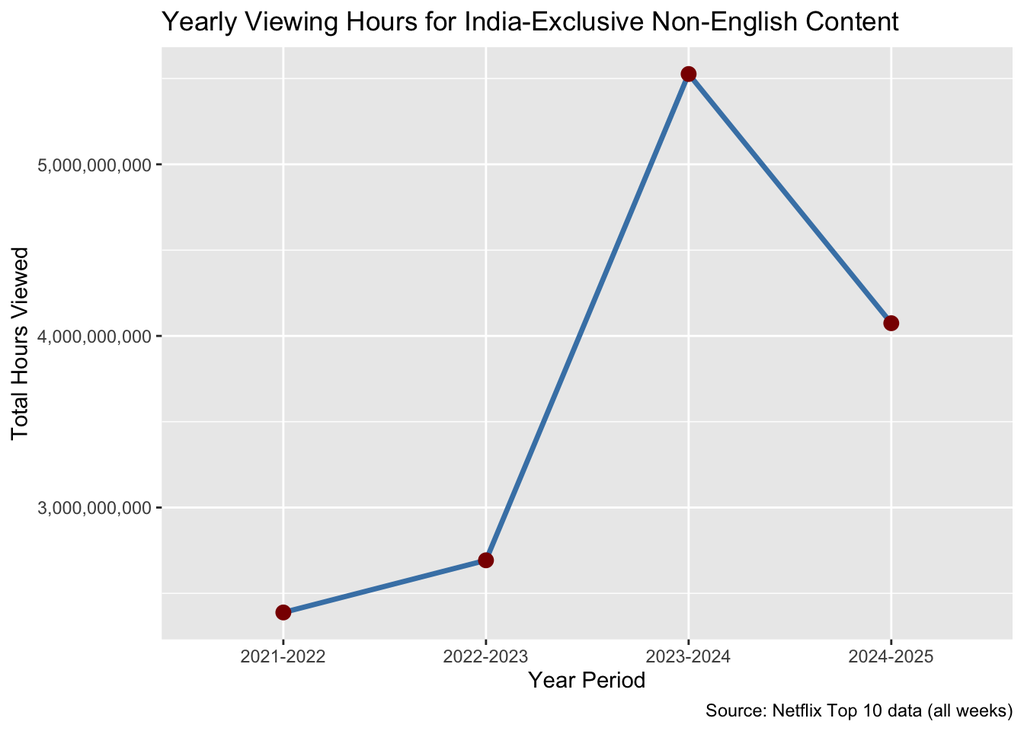

```r
ggplot(yearly_hours, aes(x = year_period, y = total_hours_viewed, group = 1)) +
  geom_line(color = "steelblue", size = 1.2) +
  geom_point(color = "darkred", size = 3) +
 labs(
    title = "Yearly Viewing Hours for India-Exclusive Non-English Content",
    x = "Year Period",
    y = "Total Hours Viewed",
    caption = "Source: Netflix Top 10 data (all weeks)"
  ) +
  scale_y_continuous(labels = comma)
```

```r
first_year <- yearly_hours$total_hours_viewed[1]
last_year  <- yearly_hours$total_hours_viewed[nrow(yearly_hours)]

total_growth <- if (first_year > 0) {
  round(((last_year - first_year) / first_year) * 100, 1)
} else { NA_real_ }

avg_annual_growth <- round(mean(yearly_hours$yoy_change, na.rm = TRUE), 1)

cat("\nGrowth Summary:\n")
```

```
##
## Growth Summary:
```

```r
cat("Total Growth (2021-2022 to 2024-2025):", total_growth, "%\n")
```

```
## Total Growth (2021-2022 to 2024-2025): 70.6 %
```

```r
cat("Average Annual Growth Rate:", avg_annual_growth, "%")
```

```
## Average Annual Growth Rate: 30.5 %
```

```r
# Define South Asian countries (excluding Nepal)
south_asian_countries <- c("India", "Pakistan", "Bangladesh", "Sri Lanka")

# Calculate unique programs by year for each country
yearly_unique_programs <- COUNTRY_TOP_10 %>%
  filter(country_name %in% south_asian_countries) %>%
  mutate(
    year_period = case_when(
      week >= as.Date("2021-07-04") & week < as.Date("2022-07-04") ~ "2021-2022",
      week >= as.Date("2022-07-04") & week < as.Date("2023-07-04") ~ "2022-2023",
      week >= as.Date("2023-07-04") & week < as.Date("2024-07-04") ~ "2023-2024",
      week >= as.Date("2024-07-04") & week <= as.Date("2025-07-05") ~ "2024-2025",
      TRUE ~ "Outside Period"
    )
  ) %>%
  filter(year_period != "Outside Period") %>%
  mutate(unique_program = paste(show_title, ifelse(is.na(season_title), "NA_SEASON", season_title), sep = " || ")) %>%
  group_by(country_name, year_period) %>%
  summarise(unique_programs_count = n_distinct(unique_program), .groups = "drop") %>%
  arrange(country_name, year_period)

# Calculate year-over-year changes
yearly_programs_with_change <- yearly_unique_programs %>%
  arrange(country_name, year_period) %>%
  group_by(country_name) %>%
  mutate(
    yoy_change = ifelse(row_number() == 1, NA,
                       round(((unique_programs_count - lag(unique_programs_count)) / lag(unique_programs_count)) * 100, 1)),
    yoy_change_formatted = ifelse(is.na(yoy_change), "N/A",
                                 paste0(ifelse(yoy_change > 0, "+", ""), yoy_change, "%"))
  ) %>%
  ungroup()

# Create separate tables for counts and changes
counts_table <- yearly_programs_with_change %>%
  select(country_name, year_period, unique_programs_count) %>%
  pivot_wider(names_from = country_name, values_from = unique_programs_count, values_fill = 0) %>%
  arrange(year_period)

changes_table <- yearly_programs_with_change %>%
  select(country_name, year_period, yoy_change_formatted) %>%
  pivot_wider(names_from = country_name, values_from = yoy_change_formatted, values_fill = "N/A") %>%
  arrange(year_period)

# Combine tables with alternating count and change columns
SOUTH_ASIA_DETAILED_ANALYSIS <- counts_table %>%
  rename(`Year Period` = year_period) %>%
  left_join(changes_table %>% rename(`Year Period` = year_period), by = "Year Period", suffix = c("_Count", "_Change")) %>%
  select(`Year Period`,
         India_Count, India_Change,
         Pakistan_Count, Pakistan_Change,
         Bangladesh_Count, Bangladesh_Change,
         `Sri Lanka_Count`, `Sri Lanka_Change`) %>%
  rename(
    `India Count` = India_Count,
    `India YoY Change` = India_Change,
    `Pakistan Count` = Pakistan_Count,
    `Pakistan YoY Change` = Pakistan_Change,
    `Bangladesh Count` = Bangladesh_Count,
    `Bangladesh YoY Change` = Bangladesh_Change,
    `Sri Lanka Count` = `Sri Lanka_Count`,
    `Sri Lanka YoY Change` = `Sri Lanka_Change`
  )

# Display the main analysis
cat("South Asian Countries - Unique Programs with Separate Rate of Change Columns:\n")
```

```
## South Asian Countries - Unique Programs with Separate Rate of Change Columns:
```

```r
SOUTH_ASIA_DETAILED_ANALYSIS %>%
  datatable(options = list(
    searching = FALSE,
    info = FALSE,
    paging = FALSE,
    scrollX = TRUE,
    columnDefs = list(
      list(className = 'dt-center', targets = "_all"),
      list(width = '80px', targets = 1:8)
    )
  ))
```

|  | Year Period | India Count | India YoY Change | Pakistan Count | Pakistan YoY Change | Bangladesh Count | Bangladesh YoY Change | Sri Lanka Count | Sri Lanka YoY Change |
| --- | --- | --- | --- | --- | --- | --- | --- | --- | --- |
| 1 | 2021-2022 | 327 | N/A | 320 | N/A | 350 | N/A | 417 | N/A |
| 2 | 2022-2023 | 347 | +6.1% | 330 | +3.1% | 341 | -2.6% | 421 | +1% |
| 3 | 2023-2024 | 353 | +1.7% | 328 | -0.6% | 334 | -2.1% | 435 | +3.3% |
| 4 | 2024-2025 | 332 | -5.9% | 353 | +7.6% | 342 | +2.4% | 446 | +2.5% |

```r
# Calculate summary statistics (excluding 2021-2022)
summary_stats <- yearly_programs_with_change %>%
  filter(year_period != "2021-2022") %>%  # Exclude baseline year
  filter(!is.na(yoy_change)) %>%
  group_by(country_name) %>%
  summarise(
    avg_yoy_change = round(mean(yoy_change, na.rm = TRUE), 1),
    total_growth = round(sum(yoy_change, na.rm = TRUE), 1),
    max_single_year_growth = round(max(yoy_change, na.rm = TRUE), 1),
    years_with_data = n(),
    .groups = "drop"
  ) %>%
  arrange(desc(avg_yoy_change))

# Display summary chart

# Display summary chart - Average YoY Change Only
cat("\n\nSummary: Average Year-over-Year Change by Country (Excluding 2021-2022 Baseline):\n")
```

```
##
##
## Summary: Average Year-over-Year Change by Country (Excluding 2021-2022 Baseline):
```

```r
summary_stats <- yearly_programs_with_change %>%
filter(year_period != "2021-2022") %>%  # Exclude baseline year
filter(!is.na(yoy_change)) %>%
group_by(country_name) %>%
summarise(
avg_yoy_change = round(mean(yoy_change, na.rm = TRUE), 1),
.groups = "drop") %>%
arrange(desc(avg_yoy_change))  # Back to descending order

summary_stats %>%
rename(
Country = country_name,
`Average YoY Change` = avg_yoy_change) %>%
datatable(options = list(
searching = FALSE,
info = FALSE,
paging = FALSE,
columnDefs = list(list(className = 'dt-center', targets = "_all"))))
```

|  | Country | Average YoY Change |
| --- | --- | --- |
| 1 | Pakistan | 3.4 |
| 2 | Sri Lanka | 2.3 |
| 3 | India | 0.6 |
| 4 | Bangladesh | -0.8 |

```r
# Identify the top performer
top_country <- summary_stats$country_name[1]
top_avg_growth <- summary_stats$avg_yoy_change[1]

cat("\nHighlight: ", top_country, " shows the greatest average year-over-year growth rate at ", top_avg_growth, "% annually.")
```

```
##
## Highlight:  Pakistan  shows the greatest average year-over-year growth rate at  3.4 % annually.
```

## Task 7:

## Press Release 3: Latin American Trends

```r
# Get top 10 Latin American countries (excluding Brazil) and combine with global data
combined_data <- COUNTRY_TOP_10 %>%
  filter(
    country_name %in% c("Colombia", "El Salvador", "Honduras",
                       "Nicaragua", "Venezuela", "Guatemala", "Ecuador",
                       "Paraguay", "Panama", "Costa Rica", "Peru",
                       "Bolivia", "Argentina", "Chile") |
    grepl("Dominican Rep", country_name, ignore.case = TRUE)
  ) %>%
  group_by(country_name) %>%
  slice_max(cumulative_weeks_in_top_10, n = 1) %>%
  arrange(desc(cumulative_weeks_in_top_10)) %>%
  head(10) %>%
  mutate(
    season_title = ifelse(is.na(season_title), "N/A", as.character(season_title))
  ) %>%
  left_join(
    GLOBAL_TOP_10 %>%
      mutate(season_title = ifelse(is.na(season_title), "N/A", as.character(season_title))) %>%
      group_by(show_title, season_title) %>%
      slice_max(week, n = 1),
    by = c("show_title", "season_title"),
    suffix = c("_country", "_global")
  ) %>%
  select(
    Country = country_name,
    `Show Title` = show_title,
    `Season Title` = season_title,
    `Cumulative Weeks in Top 10` = cumulative_weeks_in_top_10_country,
    `Global Hours Viewed` = weekly_hours_viewed,
    `Global Rank` = weekly_rank_global
  )

# Create DataTable
datatable(combined_data,
          caption = "Top Latin American Shows: Regional vs Global Performance",
          options = list(searching = FALSE, info = FALSE, paging = FALSE, columnDefs = list(list(className = 'dt-left', targets = "_all"))),
          rownames = FALSE) %>%
  formatCurrency('Global Hours Viewed',
                 currency = "",
                 digits = 0,
                 mark = ",")
```

| Country | Show Title | Season Title | Cumulative Weeks in Top 10 | Global Hours Viewed | Global Rank |
| --- | --- | --- | --- | --- | --- |
| Colombia | Pablo Escobar, el patrón del mal | Pablo Escobar, el patrón del mal: Season 1 | 102 | 7680000 | 9 |
| El Salvador | Pablo Escobar, el patrón del mal | Pablo Escobar, el patrón del mal: Season 1 | 102 | 7680000 | 9 |
| Honduras | Pasión de Gavilanes | Pasión de Gavilanes: Season 1 | 102 | 8020000 | 10 |
| Honduras | Pablo Escobar, el patrón del mal | Pablo Escobar, el patrón del mal: Season 1 | 102 | 7680000 | 9 |
| Nicaragua | Pablo Escobar, el patrón del mal | Pablo Escobar, el patrón del mal: Season 1 | 102 | 7680000 | 9 |
| Venezuela | Pablo Escobar, el patrón del mal | Pablo Escobar, el patrón del mal: Season 1 | 102 | 7680000 | 9 |
| Guatemala | Pablo Escobar, el patrón del mal | Pablo Escobar, el patrón del mal: Season 1 | 101 | 7680000 | 9 |
| Ecuador | Pasión de Gavilanes | Pasión de Gavilanes: Season 1 | 100 | 8020000 | 10 |
| Paraguay | Pablo Escobar, el patrón del mal | Pablo Escobar, el patrón del mal: Season 1 | 100 | 7680000 | 9 |
| Dominican Republic | Pablo Escobar, el patrón del mal | Pablo Escobar, el patrón del mal: Season 1 | 98 | 7680000 | 9 |

```r
# Get top 10 Latin American countries (excluding Brazil)
combined_data <- COUNTRY_TOP_10 %>%
  filter(
    country_name %in% c("Colombia", "El Salvador", "Honduras", "Nicaragua",
                       "Venezuela", "Guatemala", "Ecuador", "Paraguay",
                       "Panama", "Costa Rica", "Peru", "Bolivia",
                       "Argentina", "Chile") |
    grepl("Dominican Rep", country_name, ignore.case = TRUE)
  ) %>%
  group_by(country_name) %>%
  slice_max(cumulative_weeks_in_top_10, n = 1) %>%
  head(10) %>%
  mutate(season_title = ifelse(is.na(season_title), "N/A", season_title)) %>%
  left_join(
    GLOBAL_TOP_10 %>%
      mutate(season_title = ifelse(is.na(season_title), "N/A", season_title)) %>%
      group_by(show_title, season_title) %>%
      slice_max(week, n = 1),
    by = c("show_title", "season_title"),
    suffix = c("_country", "_global")
  ) %>%
  select(
    Country = country_name,
    `Show Title` = show_title,
    `Season Title` = season_title,
    `Cumulative Weeks` = cumulative_weeks_in_top_10_country,
    `Global Hours Viewed` = weekly_hours_viewed,
    `Global Rank` = weekly_rank_global
  )

# Display first table
datatable(combined_data,
          caption = "Top Latin American Shows: Regional vs Global Performance",
          options = list(pageLength = 10, searching = FALSE, dom = 't', ordering = FALSE),
          rownames = FALSE) %>%
  formatCurrency('Global Hours Viewed', currency = "", digits = 0, mark = ",")
```

| Country | Show Title | Season Title | Cumulative Weeks | Global Hours Viewed | Global Rank |
| --- | --- | --- | --- | --- | --- |
| Argentina | Pasión de Gavilanes | Pasión de Gavilanes: Season 1 | 82 | 8020000 | 10 |
| Bolivia | Pablo Escobar, el patrón del mal | Pablo Escobar, el patrón del mal: Season 1 | 83 | 7680000 | 9 |
| Chile | Pasión de Gavilanes | Pasión de Gavilanes: Season 1 | 75 | 8020000 | 10 |
| Colombia | Pablo Escobar, el patrón del mal | Pablo Escobar, el patrón del mal: Season 1 | 102 | 7680000 | 9 |
| Costa Rica | Pablo Escobar, el patrón del mal | Pablo Escobar, el patrón del mal: Season 1 | 96 | 7680000 | 9 |
| Dominican Republic | Pablo Escobar, el patrón del mal | Pablo Escobar, el patrón del mal: Season 1 | 98 | 7680000 | 9 |
| Ecuador | Pasión de Gavilanes | Pasión de Gavilanes: Season 1 | 100 | 8020000 | 10 |
| El Salvador | Pablo Escobar, el patrón del mal | Pablo Escobar, el patrón del mal: Season 1 | 102 | 7680000 | 9 |
| Guatemala | Pablo Escobar, el patrón del mal | Pablo Escobar, el patrón del mal: Season 1 | 101 | 7680000 | 9 |
| Honduras | Pasión de Gavilanes | Pasión de Gavilanes: Season 1 | 102 | 8020000 | 10 |

```r
# Get unique shows
show_summary <- combined_data %>%
  filter(!is.na(`Global Hours Viewed`)) %>%
  group_by(`Show Title`, `Season Title`, `Global Hours Viewed`) %>%
  summarize(Countries = n(), .groups = 'drop') %>%
  select(
    show_title = `Show Title`,
    season_title = `Season Title`,
    total_hours = `Global Hours Viewed`,
    countries = Countries
  )

# Add total row
total_row <- tibble(
  show_title = "TOTAL",
  season_title = "",
  total_hours = sum(show_summary$total_hours),
  countries = sum(show_summary$countries)
)

show_summary_final <- bind_rows(show_summary, total_row) %>%
  select(
    `Show Title` = show_title,
    `Season Title` = season_title,
    `Total Hours Viewed` = total_hours,
    `Total Episode Views` = total_hours,
    Countries = countries
  )

# Display summary table
datatable(show_summary_final,
          options = list(pageLength = 10, searching = FALSE, dom = 't', ordering = FALSE),
          rownames = FALSE) %>%
  formatCurrency(c('Total Hours Viewed', 'Total Episode Views'),
                 currency = "", digits = 0, mark = ",")
```

| Show Title | Season Title | Total Hours Viewed | Total Episode Views | Countries |
| --- | --- | --- | --- | --- |
| Pablo Escobar, el patrón del mal | Pablo Escobar, el patrón del mal: Season 1 | 7680000 | 7680000 | 6 |
| Pasión de Gavilanes | Pasión de Gavilanes: Season 1 | 8020000 | 8020000 | 4 |
| TOTAL |  | 15700000 | 15700000 | 10 |

```r
latam_countries <- c(
  "Argentina","Bolivia","Chile","Colombia","Costa Rica","Ecuador",
  "El Salvador","Guatemala","Honduras","Nicaragua","Panama","Paraguay",
  "Peru","Venezuela","Dominican Republic"
)

# Top show per country by cumulative weeks, keep top 10 countries
latam_top <- COUNTRY_TOP_10 %>%
  filter(country_name %in% latam_countries) %>%
  mutate(season_title = coalesce(season_title, "")) %>%
  group_by(country_name) %>%
  slice_max(cumulative_weeks_in_top_10, n = 1, with_ties = FALSE) %>%
  ungroup() %>%
  arrange(desc(cumulative_weeks_in_top_10)) %>%
  slice_head(n = 10)

# GLOBAL TOTALS (sum across all weeks) + best global rank
global_metrics <- GLOBAL_TOP_10 %>%
  mutate(season_title = coalesce(season_title, "")) %>%
  group_by(show_title, season_title) %>%
  summarise(
    global_total_hours = sum(weekly_hours_viewed, na.rm = TRUE),
    global_best_rank   = suppressWarnings(min(weekly_rank, na.rm = TRUE)),
    .groups = "drop"
  )

# Combine using the TOTALS, not a single week
combined_data <- latam_top %>%
  select(
    Country = country_name,
    `Show Title` = show_title,
    `Season Title` = season_title,
    `Cumulative Weeks in Top 10` = cumulative_weeks_in_top_10
  ) %>%
  left_join(global_metrics,
            by = c("Show Title" = "show_title", "Season Title" = "season_title")) %>%
  transmute(
    Country,
    `Show Title`,
    `Season Title`,
    `Cumulative Weeks in Top 10`,
    `Global Hours Viewed` = global_total_hours,   # <-- use TOTALS
    `Global Best Rank`    = global_best_rank
  )

datatable(
  combined_data,
  caption = "Top Latin American Countries’ Top Shows: Regional vs Global Performance",
  options = list(searching = FALSE, info = FALSE, paging = FALSE,
                 columnDefs = list(list(className = 'dt-left', targets = "_all"))),
  rownames = FALSE
) %>%
  formatCurrency('Global Hours Viewed', currency = "", digits = 0, mark = ",")
```

| Country | Show Title | Season Title | Cumulative Weeks in Top 10 | Global Hours Viewed | Global Best Rank |
| --- | --- | --- | --- | --- | --- |
| Colombia | Pablo Escobar, el patrón del mal | Pablo Escobar, el patrón del mal: Season 1 | 102 | 55530000 | 6 |
| El Salvador | Pablo Escobar, el patrón del mal | Pablo Escobar, el patrón del mal: Season 1 | 102 | 55530000 | 6 |
| Honduras | Pasión de Gavilanes | Pasión de Gavilanes: Season 1 | 102 | 49490000 | 7 |
| Nicaragua | Pablo Escobar, el patrón del mal | Pablo Escobar, el patrón del mal: Season 1 | 102 | 55530000 | 6 |
| Venezuela | Pablo Escobar, el patrón del mal | Pablo Escobar, el patrón del mal: Season 1 | 102 | 55530000 | 6 |
| Guatemala | Pablo Escobar, el patrón del mal | Pablo Escobar, el patrón del mal: Season 1 | 101 | 55530000 | 6 |
| Ecuador | Pasión de Gavilanes | Pasión de Gavilanes: Season 1 | 100 | 49490000 | 7 |
| Paraguay | Pablo Escobar, el patrón del mal | Pablo Escobar, el patrón del mal: Season 1 | 100 | 55530000 | 6 |
| Dominican Republic | Pablo Escobar, el patrón del mal | Pablo Escobar, el patrón del mal: Season 1 | 98 | 55530000 | 6 |
| Panama | Pablo Escobar, el patrón del mal | Pablo Escobar, el patrón del mal: Season 1 | 98 | 55530000 | 6 |